# Fish Recruitment Analysis

Author

Kelsey Webber

Published

May 16, 2023

# 1 Preparations

- Load any helper functions (functions.R)

```r
source('../R/functions.R') # includes setup fns, packages, brms DHARMA fns and SUYR Prior_Posterior fn
```

- Load required packages (functions.R)

```r
library(knitr)
library(tidyverse)
library(forcats)
library(patchwork)
library(glmmTMB)
library(MuMIn)
library(DHARMa)
library(emmeans)
library(ggeffects)
library(brms)
library(posterior)
library(rstan)
library(broom.mixed)
library(HDInterval)
library(tidybayes)
library(report)
library(vegan)
library(ggvegan)
library(butcher)
library(bayesplot)
```

- Prepare paths (functions.R)

```r
DATA_PATH <<- "../data/"
OUTPUT_PATH <<- "../output/"
FIGS_PATH <<- paste0(OUTPUT_PATH, "figures")
TABS_PATH <<- paste0(OUTPUT_PATH, "tables")

if (!dir.exists(DATA_PATH)) dir.create(DATA_PATH)
if (!dir.exists(paste0(DATA_PATH, "primary"))) dir.create(paste0(DATA_PATH, "primary"))
if (!dir.exists(paste0(DATA_PATH, "processed"))) dir.create(paste0(DATA_PATH, "processed"))
if (!dir.exists(paste0(DATA_PATH, "modelled"))) dir.create(paste0(DATA_PATH, "modelled"))
if (!dir.exists(paste0(DATA_PATH, "summarised"))) dir.create(paste0(DATA_PATH, "summarised"))
if (!dir.exists(paste0(DATA_PATH, "workspace"))) dir.create(paste0(DATA_PATH, "workspace"))

if (!dir.exists(OUTPUT_PATH)) dir.create(OUTPUT_PATH)
if (!dir.exists(FIGS_PATH)) dir.create(FIGS_PATH)
if (!dir.exists(TABS_PATH)) dir.create(TABS_PATH)
```

# 2 Load Fish Recruitment data

1. Load the data

```r
fishdata1 <- read_csv(
  paste0(
    DATA_PATH,
    "primary/fish1.csv"
  ),
  trim_ws = TRUE
)
algaedata <- read_csv(
  paste0(
    DATA_PATH,
    "primary/algae.csv"
  ),
  trim_ws = TRUE
)
```

2. Glimpse the data

```r
fishdata1 %>% glimpse()
```

```
Rows: 3,951
Columns: 13
$ Date             <chr> "25/11/2022", "25/11/2022", "25/11/2022", "25/11/2022…
$ Treatment        <chr> "BH", "BH", "BH", "BH", "BH", "W", "W", "W", "W", "W"…
$ Replicate        <dbl> 2, 2, 2, 2, 2, 2, 2, 2, 2, 2, 2, 2, 2, 2, 2, 3, 3, 3,…
$ Family           <chr> "Labridae", "Labridae", "Labridae", "Siganidae", "Sig…
$ Species          <chr> "Halichoeres miniatus", "Halichoeres miniatus", "Hali…
$ Length           <dbl> 6.0, 5.0, 3.0, 3.0, 2.0, 3.0, 3.0, 2.5, 3.0, 5.0, 5.0…
$ `Behaviour note` <chr> NA, NA, NA, NA, NA, NA, NA, NA, NA, NA, NA, NA, NA, N…
$ `ID note`        <chr> NA, NA, NA, NA, NA, NA, NA, NA, NA, NA, NA, NA, NA, "…
$ Transparency     <chr> NA, NA, NA, "medium transparency", "yellow", NA, NA, …
$ `Patch note`     <chr> NA, NA, NA, NA, NA, NA, NA, NA, NA, NA, NA, NA, NA, N…
$ Replacement      <chr> NA, NA, NA, NA, NA, NA, NA, NA, NA, NA, NA, NA, NA, N…
$ Other            <chr> NA, NA, NA, NA, NA, NA, NA, NA, NA, NA, NA, NA, NA, N…
$ count            <dbl> 1, 1, 1, 1, 1, 1, 1, 1, 1, 1, 1, 1, 1, 1, 1, 1, 1, 1,…
```

```r
algaedata %>% glimpse()
```

```
Rows: 175
Columns: 5
$ Treatment     <chr> "W", "W", "W", "W", "W", "W", "W", "W", "W", "W", "W", "…
$ Replicate     <dbl> 1, 1, 1, 1, 1, 1, 1, 1, 1, 2, 2, 2, 2, 2, 2, 2, 2, 2, 3,…
$ Thallus       <dbl> 1, 2, 3, 4, 5, 6, 7, 8, 9, 1, 2, 3, 4, 5, 6, 7, 8, 9, 1,…
$ `Length (cm)` <dbl> 27, 28, 34, 32, 39, 39, 40, 28, 28, 32, 28, 31, 32, 30, …
$ `Weight (g)`  <dbl> 116.0, 86.1, 132.8, 136.6, 69.4, 59.4, 87.9, 77.9, 110.0…
```

```r
fishdata1 %>% report::report_table()
```

```
Variable       | n_Obs | percentage_Missing | Mean |   SD | Median |  MAD |  Min |   Max | Skewness | Kurtosis | n_Entries | n_Missing
--------------------------------------------------------------------------------------------------------------------------------------
Date           |  3951 |               0.00 |      |      |        |      |      |       |          |          |     18.00 |         0
Treatment      |  3951 |               0.00 |      |      |        |      |      |       |          |          |      5.00 |         0
Replicate      |  3951 |               0.00 | 3.05 | 1.42 |   3.00 | 1.48 | 1.00 |  5.00 |    -0.04 |    -1.32 |           |
Family         |  3951 |               0.08 |      |      |        |      |      |       |          |          |     13.00 |         3
Species        |  3951 |               0.08 |      |      |        |      |      |       |          |          |     36.00 |         3
Length         |  3951 |               0.00 | 3.31 | 1.70 |   3.00 | 1.48 | 0.00 | 20.00 |     1.17 |     3.48 |           |
Behaviour note |  3951 |              99.14 |      |      |        |      |      |       |          |          |     21.00 |      3917
ID note        |  3951 |              98.79 |      |      |        |      |      |       |          |          |     34.00 |      3903
Transparency   |  3951 |              99.77 |      |      |        |      |      |       |          |          |      6.00 |      3942
Patch note     |  3951 |              98.99 |      |      |        |      |      |       |          |          |     35.00 |      3911
Replacement    |  3951 |              99.77 |      |      |        |      |      |       |          |          |      6.00 |      3942
Other          |  3951 |              99.54 |      |      |        |      |      |       |          |          |     15.00 |      3933
count          |  3951 |               0.00 | 1.00 | 0.03 |   1.00 | 0.00 | 0.00 |  1.00 |   -36.26 |  1313.66 |           |
```

```r
algaedata %>% report::report_table()
```

```
Variable    | n_Obs | percentage_Missing |  Mean |    SD | Median |   MAD |   Min |    Max | Skewness | Kurtosis | n_Entries | n_Missing
----------------------------------------------------------------------------------------------------------------------------------------
Treatment   |   175 |               0.00 |       |       |        |       |       |        |          |          |      5.00 |         0
Replicate   |   175 |               0.00 |  3.00 |  1.42 |   3.00 |  1.48 |  1.00 |   5.00 |     0.00 |    -1.30 |           |
Thallus     |   175 |               0.00 |  4.46 |  2.56 |   4.00 |  2.97 |  1.00 |   9.00 |     0.31 |    -1.12 |           |
Length (cm) |   175 |               0.00 | 29.16 |  4.73 |  29.00 |  4.45 | 19.00 |  52.00 |     0.91 |     2.32 |           |
Weight (g)  |   175 |               0.00 | 59.97 | 35.57 |  55.00 | 40.92 |  7.00 | 158.60 |     0.48 |    -0.68 |           |
```

3. Factorise and clean

```r
fishdata <- fishdata1 %>%
  select(-c(Other, Replacement, `Patch note`, Transparency, `ID note`, `Behaviour note`)) %>%

  mutate(Date = dmy(Date), #using lubridate, convert Date to proper date format
  ) %>%
  mutate_at(c(2:5), ## in the specified cols
            ~replace_na(.,"empty")) %>%   ## replace NAs with "empty" (there were no fish)
  mutate_at(c(2:5), ~factor(.) ) %>%
filter(Family != "Apogonidae")   ## removing apogonidae as they were not counted consistently (and are cryptic)
                                 ## NB - filter had to be done AFTER converting NAs to values, or they are removed

glimpse(fishdata)
```

```
Rows: 3,945
Columns: 7
$ Date      <date> 2022-11-25, 2022-11-25, 2022-11-25, 2022-11-25, 2022-11-25,…
$ Treatment <fct> BH, BH, BH, BH, BH, W, W, W, W, W, W, W, W, W, W, DM, DM, DM…
$ Replicate <fct> 2, 2, 2, 2, 2, 2, 2, 2, 2, 2, 2, 2, 2, 2, 2, 3, 3, 3, 3, 3, …
$ Family    <fct> Labridae, Labridae, Labridae, Siganidae, Siganidae, Siganida…
$ Species   <fct> Halichoeres miniatus, Halichoeres miniatus, Halichoeres mini…
$ Length    <dbl> 6.0, 5.0, 3.0, 3.0, 2.0, 3.0, 3.0, 2.5, 3.0, 5.0, 5.0, 5.0, …
$ count     <dbl> 1, 1, 1, 1, 1, 1, 1, 1, 1, 1, 1, 1, 1, 1, 1, 1, 1, 1, 1, 1, …
```

```r
algaedata <- algaedata %>%
  mutate(Treatment = factor(Treatment),
         Replicate = factor(Replicate),
         Thallus = factor(Thallus)) %>%
  rename(Length = `Length (cm)`,
         Weight = `Weight (g)`)

glimpse(algaedata)
```

```
Rows: 175
Columns: 5
$ Treatment <fct> W, W, W, W, W, W, W, W, W, W, W, W, W, W, W, W, W, W, W, W, …
$ Replicate <fct> 1, 1, 1, 1, 1, 1, 1, 1, 1, 2, 2, 2, 2, 2, 2, 2, 2, 2, 3, 3, …
$ Thallus   <fct> 1, 2, 3, 4, 5, 6, 7, 8, 9, 1, 2, 3, 4, 5, 6, 7, 8, 9, 1, 2, …
$ Length    <dbl> 27, 28, 34, 32, 39, 39, 40, 28, 28, 32, 28, 31, 32, 30, 26, …
$ Weight    <dbl> 116.0, 86.1, 132.8, 136.6, 69.4, 59.4, 87.9, 77.9, 110.0, 10…
```

```r
fishalgaedata <- algaedata %>%
  group_by(Treatment,Replicate) %>%
  summarise(plot.weight = sum(Weight)) %>%
  left_join(fishdata, .) # add plot.weight column to fishdata
fishalgaedata %>% glimpse()
```

```
Rows: 3,945
Columns: 8
$ Date        <date> 2022-11-25, 2022-11-25, 2022-11-25, 2022-11-25, 2022-11-2…
$ Treatment   <fct> BH, BH, BH, BH, BH, W, W, W, W, W, W, W, W, W, W, DM, DM, …
$ Replicate   <fct> 2, 2, 2, 2, 2, 2, 2, 2, 2, 2, 2, 2, 2, 2, 2, 3, 3, 3, 3, 3…
$ Family      <fct> Labridae, Labridae, Labridae, Siganidae, Siganidae, Sigani…
$ Species     <fct> Halichoeres miniatus, Halichoeres miniatus, Halichoeres mi…
$ Length      <dbl> 6.0, 5.0, 3.0, 3.0, 2.0, 3.0, 3.0, 2.5, 3.0, 5.0, 5.0, 5.0…
$ count       <dbl> 1, 1, 1, 1, 1, 1, 1, 1, 1, 1, 1, 1, 1, 1, 1, 1, 1, 1, 1, 1…
$ plot.weight <dbl> 389.0, 389.0, 389.0, 389.0, 389.0, 830.7, 830.7, 830.7, 83…
```

```r
#write_csv(fishalgaedata, file = paste0(DATA_PATH, "processed/fishalgaedata.csv"))
```

# 3 EDA

## 3.1 Algae EDA

```r
algae.sum <- algaedata %>%
  group_by(Treatment) %>%
  summarise(
    mean.len = mean(Length),
    n.thalli = length(Replicate),
    SE.len = sd(Length) / sqrt(length(Replicate)),
    mean.wt = mean(Weight),
    SE.wt = sd(Weight) / sqrt(length(Replicate)),
  )

algaedata %>%
  group_by(Treatment, Replicate) %>%
  summarise(plot.weight = sum(Weight)) %>%
  ungroup() %>%
  group_by(Treatment) %>%
  summarise(
    mean.plot.wt = mean(plot.weight),
    SE.plot.wt = (sd(plot.weight) / sqrt(5))
  ) %>%
  left_join(algae.sum, .) -> algae.sum

algae.sum
```

```
# A tibble: 5 × 8
  Treatment mean.len n.thalli SE.len mean.wt SE.wt mean.plot.wt SE.plot.wt
  <fct>        <dbl>    <int>  <dbl>   <dbl> <dbl>        <dbl>      <dbl>
1 BH            28.4       45  0.622    43.1 0.974         388.       7.37
2 BQ            27.3       45  0.548    18.6 0.834         168.       6.49
3 DL            29.5       15  1.16    103.  5.41          310.      15.4
4 DM            29.2       25  0.834    90.9 4.37          454.      22.5
5 W             31.7       45  0.826    86.5 3.59          779.      38.5
```

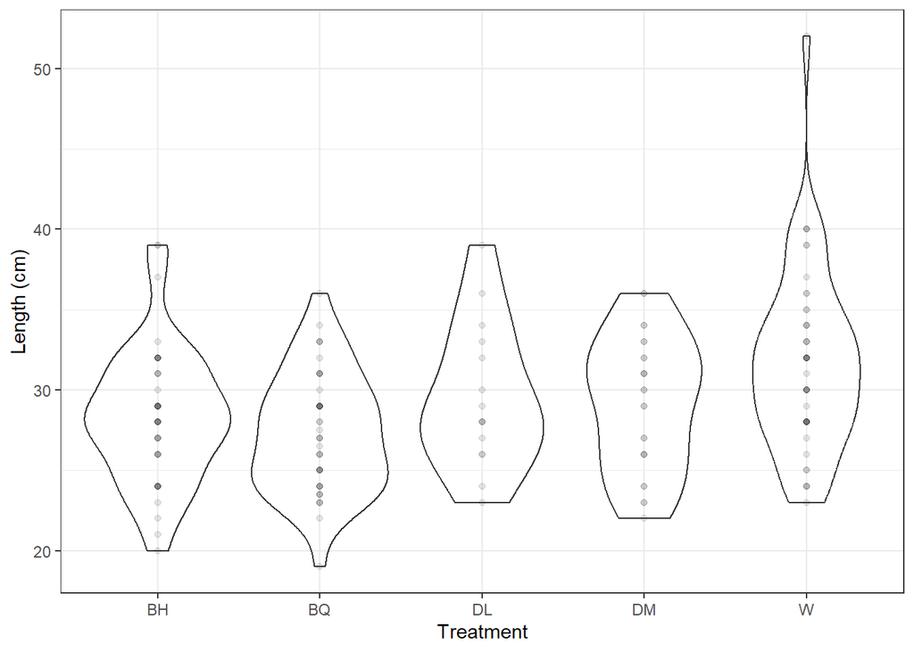

```r
g.len <- ggplot(algaedata) +
  aes(y = Length, x = Treatment) +
  geom_point(alpha = 0.1) +
  geom_violin(fill = NA) +
  labs(y = "Length (cm)") +
  theme(
    family = "calibri", text = element_text(size = 8, color = "black"),
    axis.text = element_text(size = 10),
    axis.title = element_text(size = 12),
  ) +
  theme_bw()

g.len
```

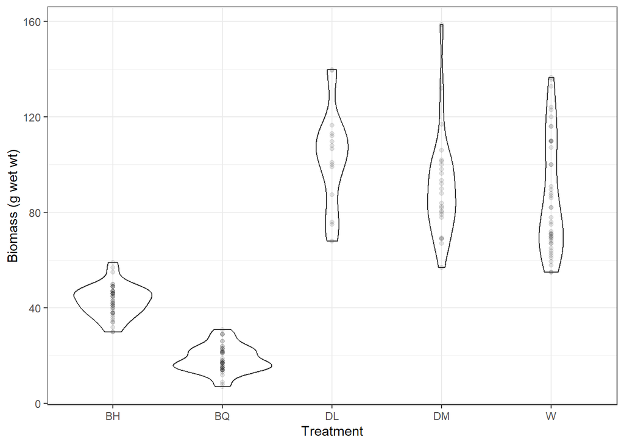

```r
g.wt <- ggplot(algaedata) +
  aes(y = Weight, x = Treatment) +
  geom_point(alpha = 0.1) +
  geom_violin(fill = NA) +
  labs(y = "Biomass (g wet wt)") +
  theme(
    family = "calibri", text = element_text(size = 8, color = "black"),
    axis.text = element_text(size = 10),
    axis.title = element_text(size = 12),
    panel.grid.major.x = element_line(colour = "transparent"),
  ) +
  theme_bw()
g.wt
```

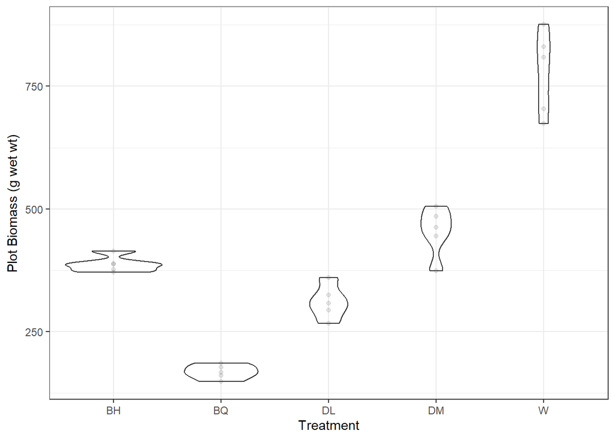

```r
g.plot.wt <- algaedata %>%
  group_by(Treatment, Replicate) %>%
  summarise(plot.weight = sum(Weight)) %>%
  ggplot() +
  aes(y = plot.weight, x = Treatment) +
  geom_point(alpha = 0.1) +
  geom_violin(fill = NA) +
  ylab(expression("Plot Biomass (g wet wt)")) +
  theme(
    family = "calibri", text = element_text(size = 8, color = "black"),
    axis.text = element_text(size = 10),
    axis.title = element_text(size = 12),
    panel.grid = element_blank()
  ) +
  theme_bw()
g.plot.wt
```

```r
ggsave(
  filename = paste0(FIGS_PATH, "/Alg.len.png"),
  g.len,
  width = 10,
  height = 5,
  dpi = 100
)
ggsave(
  filename = paste0(FIGS_PATH, "/Alg.wt.png"),
  g.wt,
  width = 10,
  height = 5,
  dpi = 100
)

ggsave(
  filename = paste0(FIGS_PATH, "/Alg.plot.wt.png"),
  g.plot.wt,
  width = 10,
  height = 5,
  dpi = 100
)
```

A bit of an outlier in Length - One plot (W5) had an extra long 52cm thallus. I checked in the video and this was not a typo. However its weight was not super high (70g). Lengths otherwise fairly similar, around 30cm

Weights per plot: BQ < DL <= BH <= DM < W

## 3.2 Fish EDA

### 3.2.1 1 Total abundance

```r
fish.sum <- fishdata %>%
  group_by(Treatment, Replicate, Date) %>%
  summarise(abundance = sum(count)) %>%
  ungroup() %>%
  group_by(Treatment, Replicate) %>%
  summarise(
    mean.abnd = mean(abundance),
    se.abnd = sd(abundance) / sqrt(length(abundance))
  )

fish.sum
```

```
# A tibble: 25 × 4
# Groups:   Treatment [5]
   Treatment Replicate mean.abnd se.abnd
   <fct>     <fct>         <dbl>   <dbl>
 1 BH        1              5.72   0.620
 2 BH        2              8.67   0.886
 3 BH        3              7.61   0.595
 4 BH        4              7.94   0.574
 5 BH        5             11.9    0.740
 6 BQ        1              5.22   0.765
 7 BQ        2              5.78   0.468
 8 BQ        3              5.78   0.432
 9 BQ        4              3.61   0.444
10 BQ        5              4.67   0.530
# … with 15 more rows
```

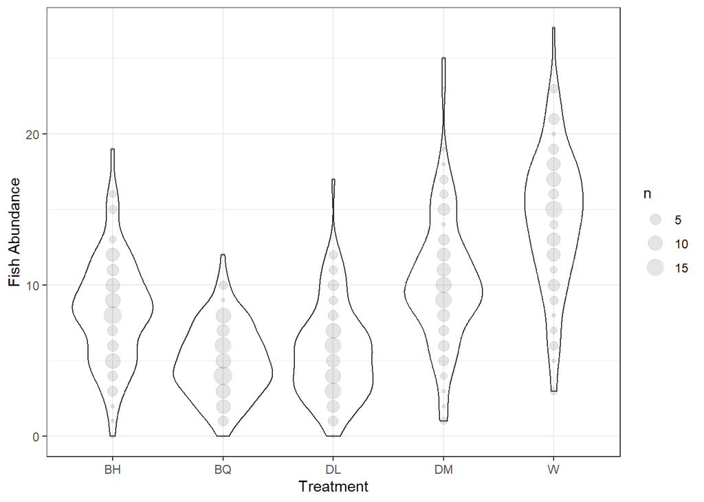

```r
g.fish.abnd1 <- fishdata %>%
  group_by(Treatment, Replicate, Date) %>%
  summarise(abundance = sum(count)) %>%
  ggplot() +
  aes(y = abundance, x = Treatment) +
  geom_count(alpha = 0.1) +
  geom_violin(fill = NA) +
  ylab(expression("Fish Abundance")) +
  theme(
    family = "calibri", text = element_text(size = 8, color = "black"),
    axis.text = element_text(size = 10),
    axis.title = element_text(size = 12),
    panel.grid = element_blank()
  ) +
  theme_bw()

g.fish.abnd1
```

```r
ggsave(
  filename = paste0(FIGS_PATH, "/EDAfish1.png"),
  g.fish.abnd1,
  width = 10,
  height = 5,
  dpi = 100
)
```

Total abundance seems to follow a similar pattern to the biomass of macroalgae. It’s also very nice that the variance doesn’t seem to differ among treatments

1.1 Total abundance over time

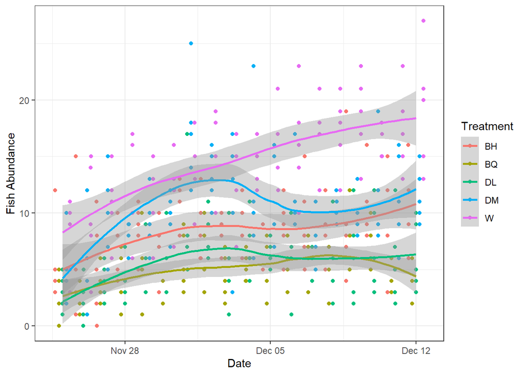

```r
g.fish.abnd.time <- fishdata %>%
  group_by(Treatment, Replicate, Date) %>%
  summarise(abundance = sum(count)) %>%
  ggplot() +
  aes(y = abundance, x = Date, colour = Treatment) +
  geom_point(position = position_jitterdodge(jitter.width = 0.02, dodge.width = 0.9), alpha = 1) +
  geom_smooth() +
  ylab(expression("Fish Abundance")) +
  theme(
    family = "calibri", text = element_text(size = 8, color = "black"),
    axis.text = element_text(size = 10),
    axis.title = element_text(size = 12),
    panel.grid = element_blank()
  ) +
  theme_bw()

g.fish.abnd.time
```

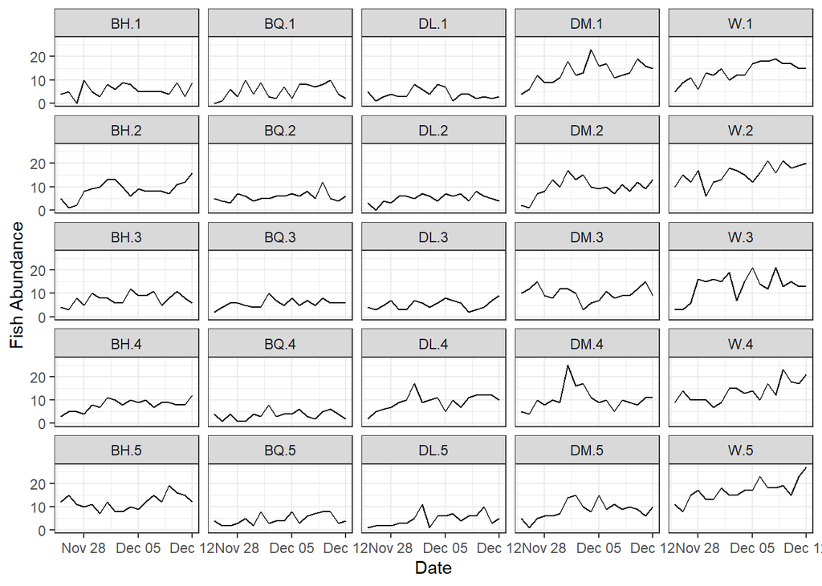

```r
ggsave(
  filename = paste0(FIGS_PATH, "/EDAfish2.png"),
  g.fish.abnd.time,
  width = 10,
  height = 5,
  dpi = 100
)

fishdata %>%
  group_by(Treatment, Replicate, Date) %>%
  summarise(abundance = sum(count)) %>%
  ggplot() +
  aes(y = abundance, x = Date) +
  geom_line() +
  facet_wrap(~ interaction(Treatment, Replicate)) +
  ylab(expression("Fish Abundance")) +
  theme(
    family = "calibri", text = element_text(size = 8, color = "black"),
    axis.text = element_text(size = 10),
    axis.title = element_text(size = 12),
    panel.grid = element_blank()
  ) +
  theme_bw()
```

Does abundance/diversity/biomass (size) change differently over time among treatments?

Yes (Abundance) – W treatment seems to continuously increase, while other treatments (esp DL and BQ) flatten early. Carrying capacity being reached earlier? DM shows a hump in abundance

1.2 Abundance vs Algal biomass

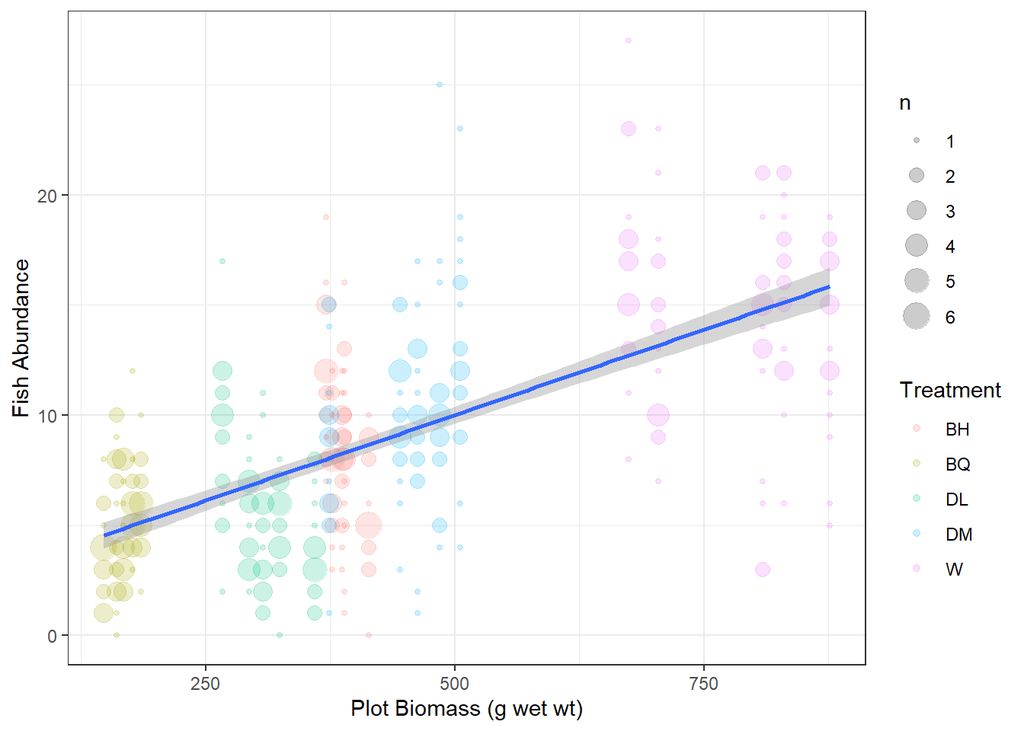

```r
fishalgaedata <- read_csv(file = paste0(DATA_PATH, "processed/fishalgaedata.csv")) %>%
  mutate_at(c(2:5), factor)

fishalgaedata %>%
  group_by(Treatment, Replicate, Date) %>%
  summarise(
    abundance = sum(count),
    x = mean(plot.weight)
  ) %>%
  ggplot() +
  aes(y = abundance, x = x) +
  geom_count(aes(colour = Treatment),
    alpha = 0.2
  ) +
  geom_smooth(method = "lm") +
  ylab(expression("Fish Abundance")) +
  xlab("Plot Biomass (g wet wt)") +
  theme(
    family = "calibri", text = element_text(size = 8, color = "black"),
    axis.text = element_text(size = 10),
    axis.title = element_text(size = 12),
    panel.grid = element_blank()
  ) +
  theme_bw() -> g.alg.fish.abnd

g.alg.fish.abnd
```

```r
ggsave(
  filename = paste0(FIGS_PATH, "/EDAfish.alg.abnd.png"),
  g.alg.fish.abnd,
  width = 10,
  height = 5,
  dpi = 100
)
```

Could the plot biomass be used as a predictor of total abundance?- yeah seems so

### 3.2.2 2 Species Richness

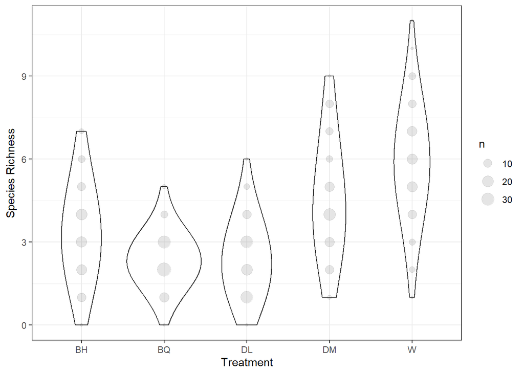

```r
g.sp.richness <- fishdata %>%
  group_by(Treatment, Replicate, Date) %>%
  summarise(
    sp.richness = if_else(Species != "empty",
      true = length(unique(Species)),
      false = 0
    )
  ) %>%
  distinct() %>%
  ggplot() +
  aes(x = Treatment, y = sp.richness) +
  geom_count(alpha = 0.1) +
  geom_violin(
    fill = NA,
    adjust = 2.5
  ) +
  ylab(expression("Species Richness")) +
  theme(
    family = "calibri", text = element_text(size = 8, color = "black"),
    axis.text = element_text(size = 10),
    axis.title = element_text(size = 12),
    panel.grid = element_blank()
  ) +
  theme_bw()

g.sp.richness
```

```r
ggsave(
  filename = paste0(FIGS_PATH, "/EDAfish.sp1.png"),
  g.sp.richness,
  width = 10,
  height = 5,
  dpi = 100
)
```

Similarly to abundance, richness seems to follow a similar pattern to the biomass of macroalgae.

2.1 Species richness over time

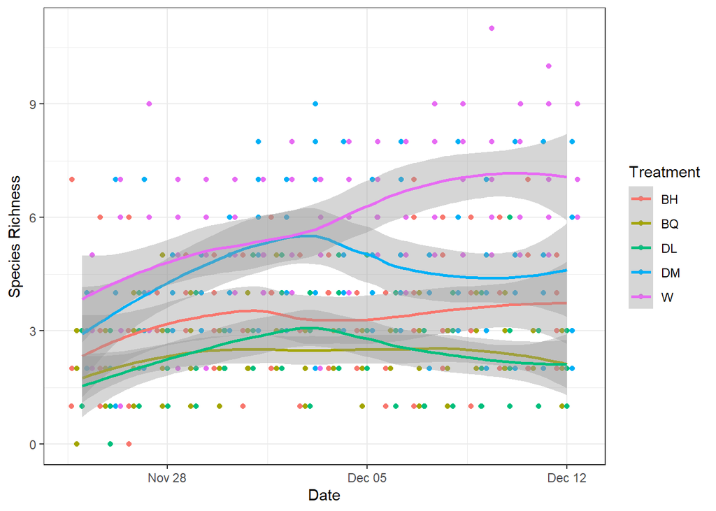

```r
g.sp.time <- fishdata %>%
  group_by(Treatment, Replicate, Date) %>%
  summarise(sp.richness = if_else(Species != "empty",
    true = length(unique(Species)),
    false = 0
  )) %>%
  distinct() %>%
  ggplot() +
  aes(y = sp.richness, x = Date, colour = Treatment) +
  geom_point(position = position_jitterdodge(jitter.width = 0.02, dodge.width = 0.9), alpha = 1) +
  geom_smooth() +
  ylab(expression("Species Richness")) +
  theme(
    family = "calibri", text = element_text(size = 8, color = "black"),
    axis.text = element_text(size = 10),
    axis.title = element_text(size = 12),
    panel.grid = element_blank()
  ) +
  theme_bw()

g.sp.time
```

```r
ggsave(
  filename = paste0(FIGS_PATH, "/EDAfish.sp2.png"),
  g.sp.time,
  width = 10,
  height = 5,
  dpi = 100
)
```

Does abundance/diversity/biomass (size) change differently over time among treatments?

For diversity, W again seems to continuously increase, while other treatments (esp DL and BQ) flatten early. DM shows an even more prominent hump in abundance around day 8.

2.2 Species Richness vs Algal biomass

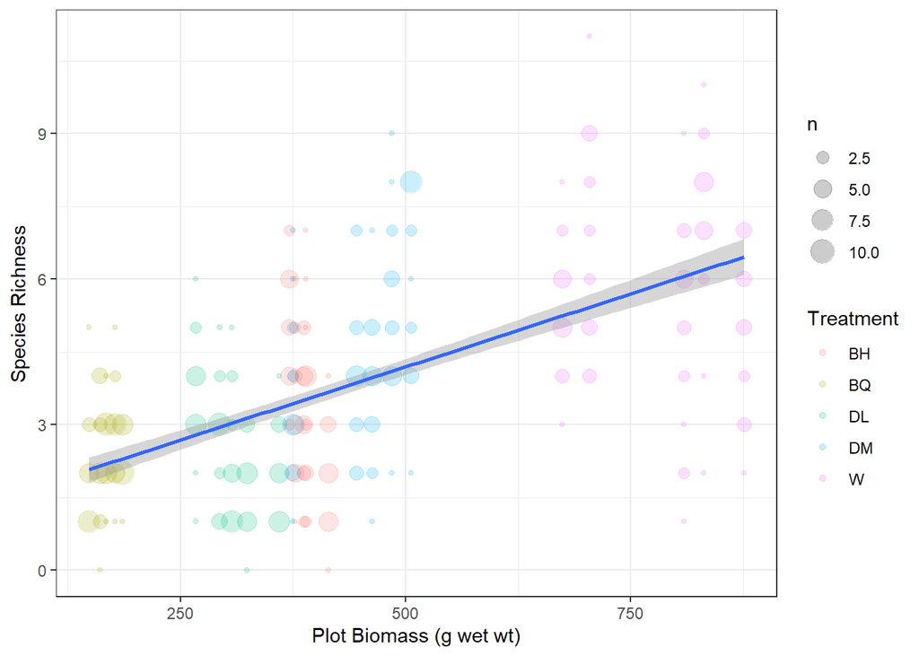

```r
fishalgaedata %>%
  group_by(Treatment, Replicate, Date) %>%
  summarise(
    sp.richness = if_else(Species != "empty",
      true = length(unique(Species)),
      false = 0
    ),
    x = mean(plot.weight)
  ) %>%
  distinct() %>%
  ggplot() +
  aes(y = sp.richness, x = x) +
  geom_count(aes(colour = Treatment),
    alpha = 0.2
  ) +
  geom_smooth(method = "lm") +
  ylab(expression("Species Richness")) +
  xlab("Plot Biomass (g wet wt)") +
  theme(
    family = "calibri", text = element_text(size = 8, color = "black"),
    axis.text = element_text(size = 10),
    axis.title = element_text(size = 12),
    panel.grid = element_blank()
  ) +
  theme_bw() -> g.alg.fish.sp

g.alg.fish.sp
```

```r
ggsave(
  filename = paste0(FIGS_PATH, "/EDAfish.alg.sp.png"),
  g.alg.fish.sp,
  width = 10,
  height = 5,
  dpi = 100
)
```

Could the plot biomass be used as a predictor of diversity ?- yeah seems so

### 3.2.3 3 Find Common Species

```r
sp.abnd <- fishalgaedata %>%
  group_by(Species) %>%
  summarise(total.abnd = sum(count)) %>%
  mutate(abnd.prop = total.abnd / sum(total.abnd)) %>%
  arrange(-total.abnd) %>%
  mutate(cum.prop = cumsum(abnd.prop))

days.observed <- fishalgaedata %>%
  group_by(Species, Date) %>%
  summarise(total.abnd = sum(count)) %>%
  count(sort = TRUE)

sp.abnd <- sp.abnd %>%
  left_join(days.observed) %>%
  rename(days.observed = n)

sp.abnd %>% head(10)
```

```
# A tibble: 10 × 5
   Species                  total.abnd abnd.prop cum.prop days.observed
   <fct>                         <dbl>     <dbl>    <dbl>         <int>
 1 Halichoeres miniatus           1862   0.472      0.472            18
 2 Petroscirtes sp.                587   0.149      0.621            18
 3 Pomacentrus tripunctatus        476   0.121      0.742            18
 4 Siganus doliatus                381   0.0967     0.839            18
 5 Lethrinus atkinsoni             133   0.0337     0.872            18
 6 Siganus fuscescens              101   0.0256     0.898            18
 7 Stethojulis interrupta           82   0.0208     0.919            17
 8 Stethojulis strigiventer         64   0.0162     0.935            18
 9 Lethrinus variegatus             41   0.0104     0.945            17
10 Siganus lineatus                 37   0.00939    0.955            10
```

```r
write_csv(sp.abnd, paste0(DATA_PATH, "summarised/species.abundance.csv"))
```

The top 6 (Halichoeres miniatus to Siganus fuscescens) collectively accounted for 90% of total abundance, each individually accounted for more than 2% of total abundance and appeared every day. Only Steothjulis strigiventer also appeared every day (but why analyse it if not something else more abundant?) Using just the top 6 or less makes sense

### 3.2.4 4 Common species patterns

```r
commondata <- fishalgaedata %>%
  filter(Species %in% paste0(sp.abnd$Species[1:6])) %>%
  droplevels()
glimpse(commondata)
```

```
Rows: 3,540
Columns: 8
$ Date        <date> 2022-11-25, 2022-11-25, 2022-11-25, 2022-11-25, 2022-11-2…
$ Treatment   <fct> BH, BH, BH, BH, BH, W, W, W, W, W, W, W, DM, DM, DM, DM, D…
$ Replicate   <fct> 2, 2, 2, 2, 2, 2, 2, 2, 2, 2, 2, 2, 3, 3, 3, 3, 3, 3, 3, 3…
$ Family      <fct> Labridae, Labridae, Labridae, Siganidae, Siganidae, Sigani…
$ Species     <fct> Halichoeres miniatus, Halichoeres miniatus, Halichoeres mi…
$ Length      <dbl> 6.0, 5.0, 3.0, 3.0, 2.0, 3.0, 3.0, 2.5, 3.0, 5.0, 7.0, 4.0…
$ count       <dbl> 1, 1, 1, 1, 1, 1, 1, 1, 1, 1, 1, 1, 1, 1, 1, 1, 1, 1, 1, 1…
$ plot.weight <dbl> 389.0, 389.0, 389.0, 389.0, 389.0, 830.7, 830.7, 830.7, 83…
```

```r
commondata$Species %>% levels()
```

```
[1] "Halichoeres miniatus"     "Lethrinus atkinsoni"
[3] "Petroscirtes sp."         "Pomacentrus tripunctatus"
[5] "Siganus doliatus"         "Siganus fuscescens"
```

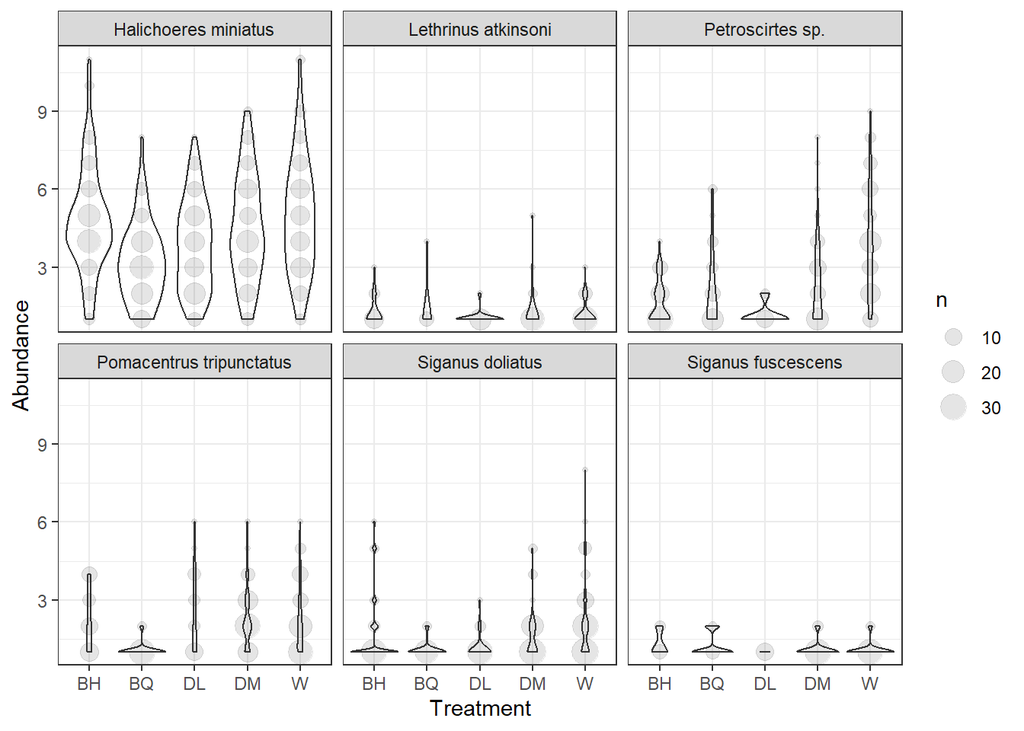

```r
commondata %>%
  group_by(Treatment, Replicate, Date, Species) %>%
  summarise(abundance = sum(count)) %>%
  ggplot() +
  aes(y = abundance, x = Treatment) +
  geom_count(alpha = 0.1) +
  geom_violin(fill = NA) +
  facet_wrap(~Species) +
  ylab("Abundance") +
  theme(
    family = "calibri", text = element_text(size = 8, color = "black"),
    axis.text = element_text(size = 10),
    axis.title = element_text(size = 12),
    panel.grid = element_blank()
  ) +
  theme_bw() -> g.common.abnd

g.common.abnd
```

```r
ggsave(
  filename = paste0(FIGS_PATH, "/EDAfish.common.png"),
  g.common.abnd,
  width = 10,
  height = 5,
  dpi = 100
)
```

Petroscirtes and Siganus doliatus and maybe Pomacentrus tripunctatus show a somewhat similar patttern to that of plot biomass, but lots of skew. Halichoeres miniatus shows a fairly similar abundance among treatments (although I wonder if the size distributions may vary?) Maybe not enough data for Lethrinus atkinsoni and Siganus fuscescens

4.1 Common species over time

```r
commondata %>%
  group_by(Treatment, Replicate, Date, Species) %>%
  summarise(abundance = sum(count)) %>%
  ggplot() +
  aes(y = abundance, x = Date, colour = Treatment) +
  geom_point(position = position_jitterdodge(jitter.width = 0.02, dodge.width = 0.9), alpha = 1) +
  geom_smooth() +
  facet_wrap(~Species) +
  ylab("Abundance") +
  theme(
    family = "calibri", text = element_text(size = 8, color = "black"),
    axis.text = element_text(size = 10),
    axis.title = element_text(size = 12),
    panel.grid = element_blank()
  ) +
  theme_bw() -> g.common.abnd.time

ggsave(
  filename = paste0(FIGS_PATH, "/EDAfish.common.time.png"),
  g.common.abnd.time,
  width = 10,
  height = 5,
  dpi = 100
)
```

H. miniatus, Petroscirtes sp. and tripunctatus accumulated over time, particularly in treatments W, BH and DM (H. miniatus), W (Petroscirtes) and all except BQ in P. tripunctatus. S doliatus declined in abundance over time to making W, BH and DM, which started off with more, approximately similar to the other treatments after ~6 days. L atkinsoni and S. fuscescens show no clear pattern (not enough data)

4.2 Common sp vs algal biomass

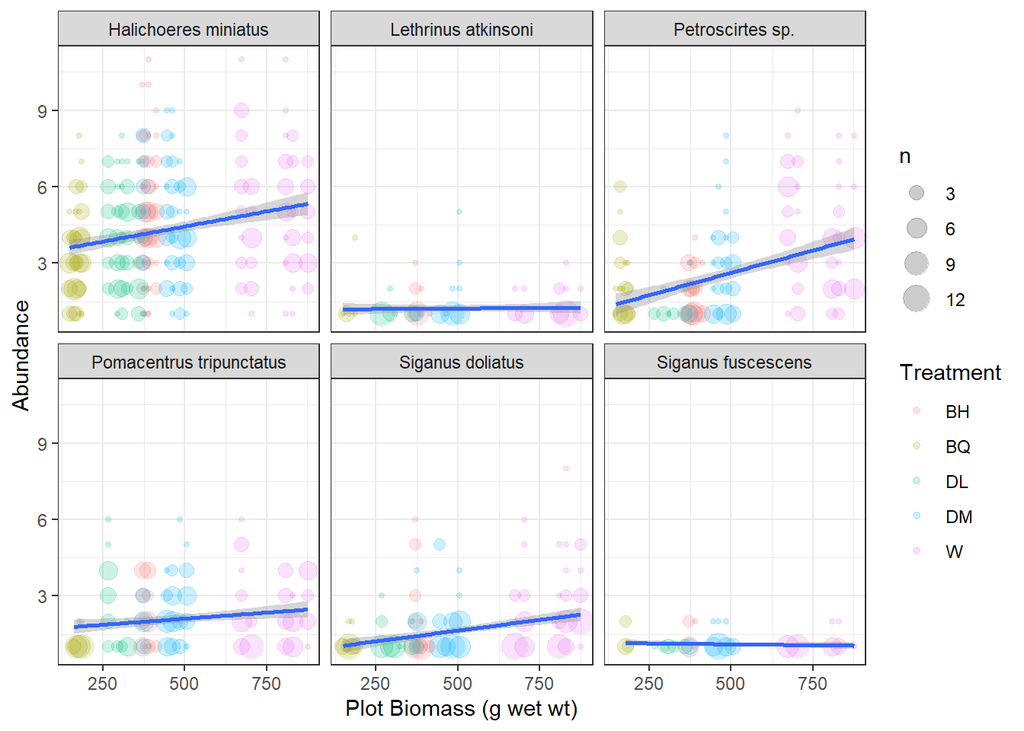

```r
commondata %>%
  group_by(Treatment, Replicate, Date, Species) %>%
  summarise(
    abundance = sum(count),
    x = mean(plot.weight)
  ) %>%
  ggplot() +
  aes(y = abundance, x = x) +
  geom_count(aes(colour = Treatment),
    alpha = 0.2
  ) +
  geom_smooth(method = "lm") +
  facet_wrap(~Species) +
  ylab("Abundance") +
  xlab("Plot Biomass (g wet wt)") +
  theme(
    family = "calibri", text = element_text(size = 8, color = "black"),
    axis.text = element_text(size = 10),
    axis.title = element_text(size = 12),
    panel.grid = element_blank()
  ) +
  theme_bw() -> g.common.abnd.alg
g.common.abnd.alg
```

```r
ggsave(
  filename = paste0(FIGS_PATH, "/EDAfish.common.alg.png"),
  g.common.abnd.alg,
  width = 10,
  height = 5,
  dpi = 100
)
```

Unlikely to be worth exploring L. atkinsoni and S. fuscescens, but the rest show a bit of a positive relationship (including H. miniatus kind of). Petroscirtes sp. the strongest relationship

### 3.2.5 5 Size distributions

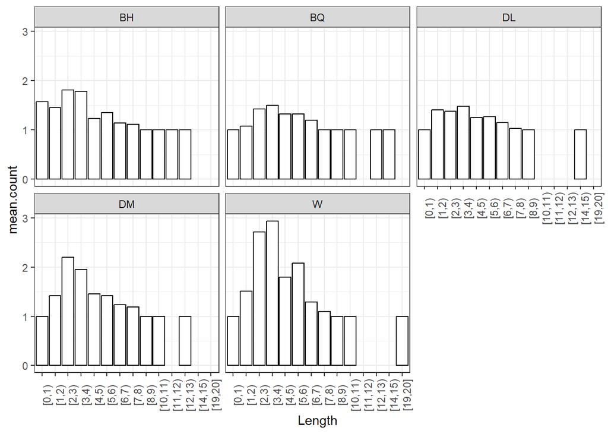

```r
fishalgaedata <- read_csv(file = paste0(DATA_PATH, "processed/fishalgaedata.csv")) %>%
  mutate_at(c(2:5), factor)
dat <- fishalgaedata %>%
  filter(!Family == "empty") %>%
  group_by(Length, Date, Treatment, Replicate) %>%
  summarise(count.per.day = sum(count)) %>%
  group_by(Treatment,
    Length = cut(Length,
      breaks = seq(0, max(Length), 1),
      right = FALSE,
      include.lowest = TRUE
    )
  ) %>%
  summarise(
    mean.count = mean(count.per.day),
    med.count = median(count.per.day)
  )
g <- dat %>% ggplot(aes(x = Length)) +
  geom_col(aes(y = mean.count),
    colour = "black", fill = "white"
  ) +
  facet_wrap(~Treatment) +
  theme_bw() +
  theme(axis.text.x = element_text(angle = 90))

g
```

This plot shows the mean number of fish of each length category (bin width 1) per day for each treatment, all fish combined. While the overall centre of mass is similar among treatments (around 2-5), the height of the peaks appear to increase with increasing plot biomass (treatments BQ=DL<BH<DM<W)

```r
sp.abnd <- read_csv(paste0(DATA_PATH, "summarised/species.abundance.csv"))

commondata <- fishalgaedata %>%
  filter(Species %in% paste0(sp.abnd$Species[1:6])) %>%
  droplevels()
glimpse(commondata)
```

```
Rows: 3,540
Columns: 8
$ Date        <date> 2022-11-25, 2022-11-25, 2022-11-25, 2022-11-25, 2022-11-2…
$ Treatment   <fct> BH, BH, BH, BH, BH, W, W, W, W, W, W, W, DM, DM, DM, DM, D…
$ Replicate   <fct> 2, 2, 2, 2, 2, 2, 2, 2, 2, 2, 2, 2, 3, 3, 3, 3, 3, 3, 3, 3…
$ Family      <fct> Labridae, Labridae, Labridae, Siganidae, Siganidae, Sigani…
$ Species     <fct> Halichoeres miniatus, Halichoeres miniatus, Halichoeres mi…
$ Length      <dbl> 6.0, 5.0, 3.0, 3.0, 2.0, 3.0, 3.0, 2.5, 3.0, 5.0, 7.0, 4.0…
$ count       <dbl> 1, 1, 1, 1, 1, 1, 1, 1, 1, 1, 1, 1, 1, 1, 1, 1, 1, 1, 1, 1…
$ plot.weight <dbl> 389.0, 389.0, 389.0, 389.0, 389.0, 830.7, 830.7, 830.7, 83…
```

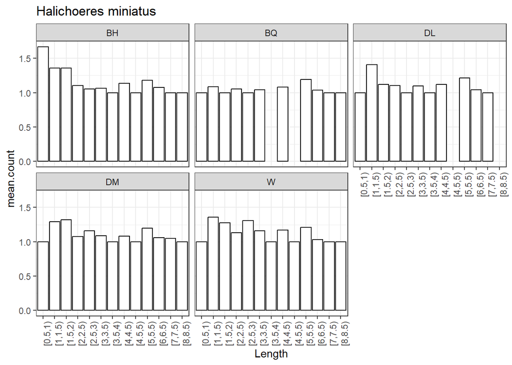

```r
dat <- commondata %>%
  filter(!Family == "empty") %>%
  group_by(Species, Length, Date, Treatment, Replicate) %>%
  summarise(count.per.day = sum(count)) %>%
  group_by(Species, Treatment,
    Length = cut(Length,
      breaks = seq(0, max(Length), 0.5),
      right = FALSE,
      include.lowest = TRUE
    )
  ) %>%
  summarise(
    med.count = median(count.per.day),
    mean.count = mean(count.per.day)
  )

g.hm <- dat %>%
  filter(Species == "Halichoeres miniatus") %>%
  ggplot(aes(x = Length)) +
  geom_col(aes(y = mean.count),
    colour = "black", fill = "white"
  ) +
  facet_wrap(~Treatment) +
  theme_bw() +
  labs(title = "Halichoeres miniatus") +
  theme(axis.text.x = element_text(angle = 90))

g.ps <- dat %>%
  filter(Species == "Petroscirtes sp.") %>%
  ggplot(aes(x = Length)) +
  geom_col(aes(y = mean.count),
    colour = "black", fill = "white"
  ) +
  facet_wrap(~Treatment) +
  theme_bw() +
  labs(title = "Petroscirtes sp.") +
  theme(axis.text.x = element_text(angle = 90))

g.sd <- dat %>%
  filter(Species == "Siganus doliatus") %>%
  ggplot(aes(x = Length)) +
  geom_col(aes(y = mean.count),
    colour = "black", fill = "white"
  ) +
  facet_wrap(~Treatment) +
  theme_bw() +
  labs(title = "Siganus doliatus") +
  theme(axis.text.x = element_text(angle = 90))

g.pt <- dat %>%
  filter(Species == "Pomacentrus tripunctatus") %>%
  ggplot(aes(x = Length)) +
  geom_col(aes(y = mean.count),
    colour = "black", fill = "white"
  ) +
  facet_wrap(~Treatment) +
  theme_bw() +
  labs(title = "Pomacentrus tripunctatus") +
  theme(axis.text.x = element_text(angle = 90))

g.la <- dat %>%
  filter(Species == "Lethrinus atkinsoni") %>%
  ggplot(aes(x = Length)) +
  geom_col(aes(y = mean.count),
    colour = "black", fill = "white"
  ) +
  facet_wrap(~Treatment) +
  theme_bw() +
  labs(title = "Lethrinus atkinsoni") +
  theme(axis.text.x = element_text(angle = 90))

g.sf <- dat %>%
  filter(Species == "Siganus fuscescens") %>%
  ggplot(aes(x = Length)) +
  geom_col(aes(y = mean.count),
    colour = "black", fill = "white"
  ) +
  facet_wrap(~Treatment) +
  theme_bw() +
  labs(title = "Siganus fuscescens") +
  theme(axis.text.x = element_text(angle = 90))

g.hm
```

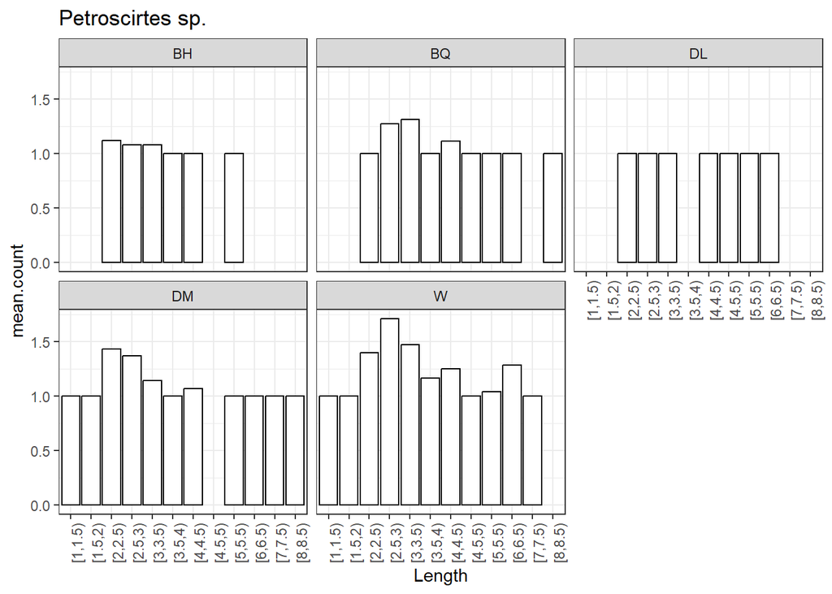

```r
g.ps
```

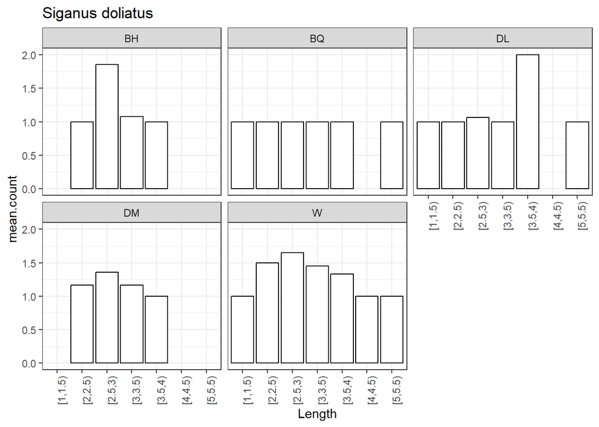

```r
g.sd
```

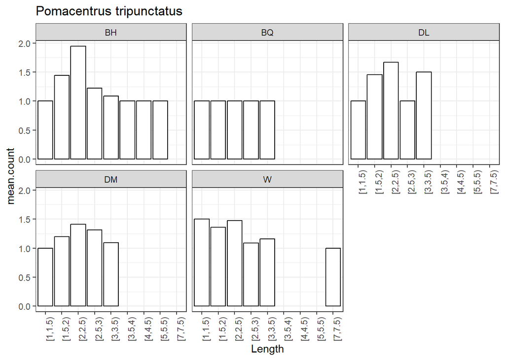

```r
g.pt
```

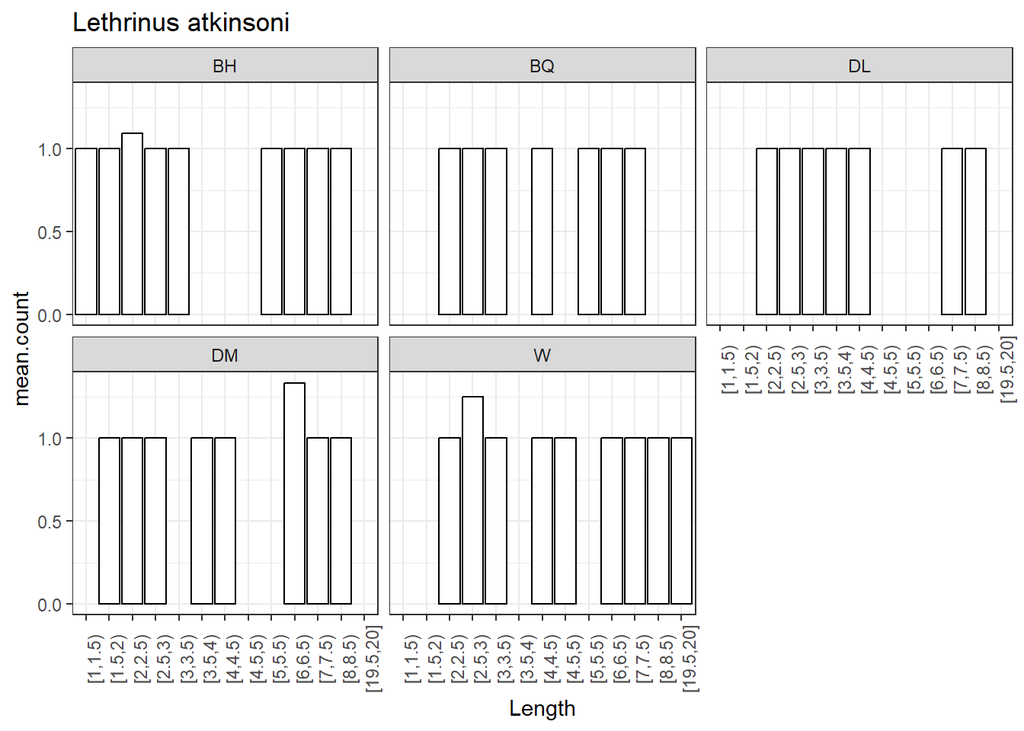

```r
g.la
```

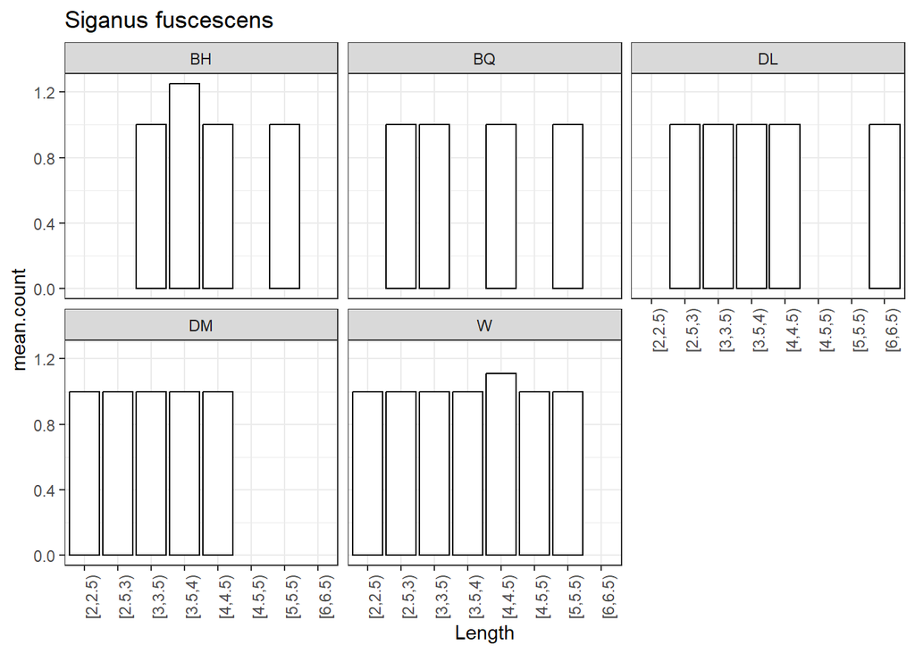

```r
g.sf
```

```r
ggsave(
  filename = paste0(FIGS_PATH, "/EDAfish.hm.size.trt.png"),
  g.hm,
  width = 10,
  height = 5,
  dpi = 100
)
ggsave(
  filename = paste0(FIGS_PATH, "/EDAfish.ps.size.trt.png"),
  g.ps,
  width = 10,
  height = 5,
  dpi = 100
)
ggsave(
  filename = paste0(FIGS_PATH, "/EDAfish.sd.size.trt.png"),
  g.sd,
  width = 10,
  height = 5,
  dpi = 100
)
ggsave(
  filename = paste0(FIGS_PATH, "/EDAfish.pt.size.trt.png"),
  g.pt,
  width = 10,
  height = 5,
  dpi = 100
)
ggsave(
  filename = paste0(FIGS_PATH, "/EDAfish.la.size.trt.png"),
  g.la,
  width = 10,
  height = 5,
  dpi = 100
)
ggsave(
  filename = paste0(FIGS_PATH, "/EDAfish.sf.size.trt.png"),
  g.sf,
  width = 10,
  height = 5,
  dpi = 100
)
```

It probably isn’t worth exploring S.fuscescens and L. atkinsoni further (too many 1s and not much else)

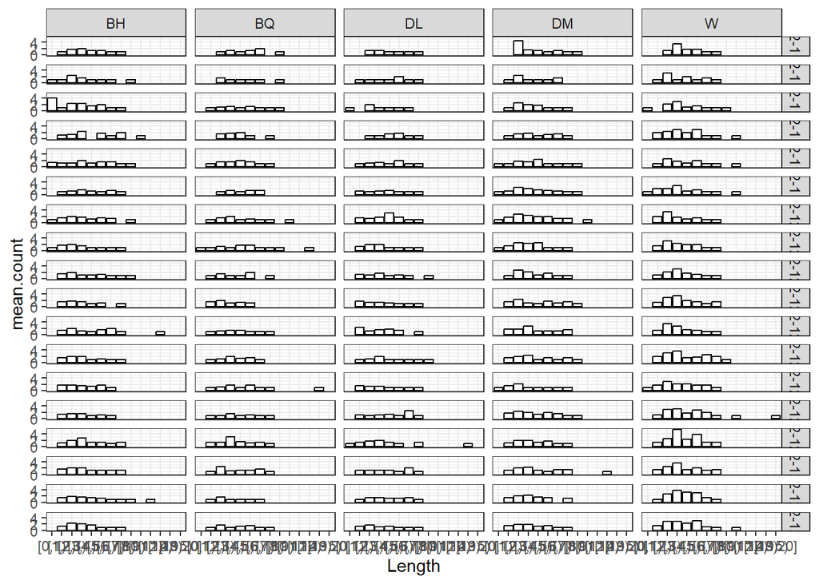

```r
dat <- fishalgaedata %>%
  filter(!Family == "empty") %>%
  group_by(Length, Date, Treatment, Replicate) %>%
  summarise(count.per.day = sum(count)) %>%
  group_by(Treatment, Date,
    Length = cut(Length,
      breaks = seq(0, max(Length), 1),
      right = FALSE,
      include.lowest = TRUE
    )
  ) %>%
  summarise(
    mean.count = mean(count.per.day),
    med.count = median(count.per.day)
  )

all.length.date <- dat %>% ggplot(aes(x = Length)) +
  geom_col(aes(y = mean.count),
    colour = "black", fill = "white"
  ) +
  facet_grid(rows = vars(Date), cols = vars(Treatment)) +
  theme_bw()

dat <- fishalgaedata %>%
  filter(Species == "Petroscirtes sp.") %>%
  group_by(Length, Date, Treatment, Replicate) %>%
  summarise(count.per.day = sum(count)) %>%
  group_by(Treatment, Date,
    Length = cut(Length,
      breaks = seq(0, max(Length), 0.5),
      right = FALSE,
      include.lowest = TRUE
    )
  ) %>%
  summarise(
    mean.count = mean(count.per.day),
    med.count = median(count.per.day)
  )

petro.length.date <- dat %>%
  ggplot(aes(x = Length)) +
  geom_col(aes(y = mean.count),
    colour = "black", fill = "white"
  ) +
  facet_grid(rows = vars(Date), cols = vars(Treatment)) +
  labs(title = "Petroscirtes sp.") +
  theme_bw()

dat <- fishalgaedata %>%
  filter(Species == "Siganus doliatus") %>%
  group_by(Length, Date, Treatment, Replicate) %>%
  summarise(count.per.day = sum(count)) %>%
  group_by(Treatment, Date,
    Length = cut(Length,
      breaks = seq(0, max(Length), 0.5),
      right = FALSE,
      include.lowest = TRUE
    )
  ) %>%
  summarise(
    mean.count = mean(count.per.day),
    med.count = median(count.per.day)
  )
doli.length.date <- dat %>%
  ggplot(aes(x = Length)) +
  geom_col(aes(y = mean.count),
    colour = "black", fill = "white"
  ) +
  facet_grid(rows = vars(Date), cols = vars(Treatment)) +
  labs(title = "Siganus doliatus") +
  theme_bw()

all.length.date
```

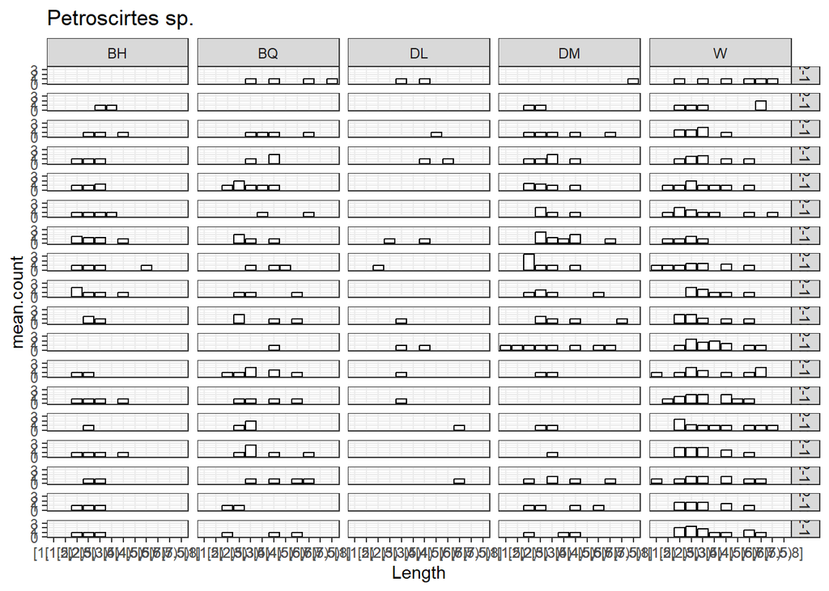

```r
petro.length.date
```

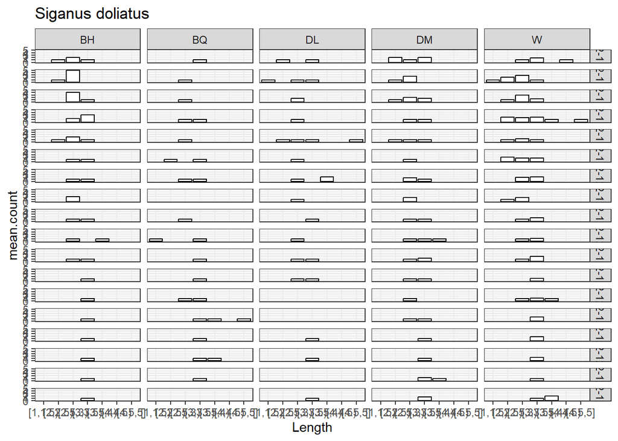

```r
doli.length.date
```

```r
ggsave(
  filename = paste0(FIGS_PATH, "/EDAfish.all.length.date.png"),
  all.length.date,
  width = 40,
  height = 25,
  dpi = 100
)

ggsave(
  filename = paste0(FIGS_PATH, "/EDAfish.petro.length.date.png"),
  petro.length.date,
  width = 40,
  height = 25,
  dpi = 100
)
ggsave(
  filename = paste0(FIGS_PATH, "/EDAfish.doli.length.date.png"),
  doli.length.date,
  width = 40,
  height = 25,
  dpi = 100
)
```

These plots show the mean number of fish of each length category averaged by Treatment and plotted for each day separately Not much of a pattern really to see - no obvious shift in size distributions over time for all fish combined, Petroscrites sp. or for Siganus doliatus

# 4 Univariate modelling

## 4.1 Total abundance

```r
fishalgaedata <- read_csv(file = paste0(DATA_PATH, "processed/fishalgaedata.csv")) %>%
  mutate_at(c(2:5), factor)
glimpse(fishalgaedata)
```

```
Rows: 3,945
Columns: 8
$ Date        <date> 2022-11-25, 2022-11-25, 2022-11-25, 2022-11-25, 2022-11-2…
$ Treatment   <fct> BH, BH, BH, BH, BH, W, W, W, W, W, W, W, W, W, W, DM, DM, …
$ Replicate   <fct> 2, 2, 2, 2, 2, 2, 2, 2, 2, 2, 2, 2, 2, 2, 2, 3, 3, 3, 3, 3…
$ Family      <fct> Labridae, Labridae, Labridae, Siganidae, Siganidae, Sigani…
$ Species     <fct> Halichoeres miniatus, Halichoeres miniatus, Halichoeres mi…
$ Length      <dbl> 6.0, 5.0, 3.0, 3.0, 2.0, 3.0, 3.0, 2.5, 3.0, 5.0, 5.0, 5.0…
$ count       <dbl> 1, 1, 1, 1, 1, 1, 1, 1, 1, 1, 1, 1, 1, 1, 1, 1, 1, 1, 1, 1…
$ plot.weight <dbl> 389.0, 389.0, 389.0, 389.0, 389.0, 830.7, 830.7, 830.7, 83…
```

```r
fish.sp.abnd <- fishalgaedata %>%
  group_by(Treatment, Replicate, Date) %>%
  summarise(
    abundance = sum(count),
    sp.richness = if_else(Species != "empty",
      true = length(unique(Species)),
      false = 0
    ),
    plot.weight = plot.weight
  ) %>%
  distinct() %>%
  mutate(
    plotID = factor(paste0(Treatment, Replicate)),
    Density = recode_factor(Treatment,
      "W" = 9, "BH" = 9, "BQ" = 9,
      "DM" = 5, "DL" = 3
    )
  ) %>%
  as.data.frame()

fish.sp.abnd %>% glimpse()
```

```
Rows: 450
Columns: 8
$ Treatment   <fct> BH, BH, BH, BH, BH, BH, BH, BH, BH, BH, BH, BH, BH, BH, BH…
$ Replicate   <fct> 1, 1, 1, 1, 1, 1, 1, 1, 1, 1, 1, 1, 1, 1, 1, 1, 1, 1, 2, 2…
$ Date        <date> 2022-11-25, 2022-11-26, 2022-11-27, 2022-11-28, 2022-11-2…
$ abundance   <dbl> 4, 5, 0, 10, 5, 3, 8, 6, 9, 8, 5, 5, 5, 5, 4, 9, 3, 9, 5, …
$ sp.richness <dbl> 1, 1, 0, 3, 3, 2, 3, 2, 1, 2, 2, 1, 1, 2, 1, 4, 2, 3, 2, 1…
$ plot.weight <dbl> 414, 414, 414, 414, 414, 414, 414, 414, 414, 414, 414, 414…
$ plotID      <fct> BH1, BH1, BH1, BH1, BH1, BH1, BH1, BH1, BH1, BH1, BH1, BH1…
$ Density     <fct> 9, 9, 9, 9, 9, 9, 9, 9, 9, 9, 9, 9, 9, 9, 9, 9, 9, 9, 9, 9…
```

```r
fish.sp.abnd$Density %>% levels()
```

```
[1] "9" "3" "5"
```

### 4.1.1 Fit model

```r
abnd.glmmTMB1 <- glmmTMB(abundance ~ 1 + (1 | plotID),
  data = fish.sp.abnd,
  family = poisson(link = "log"),
  REML = TRUE
)

abnd.glmmTMB2 <- update(abnd.glmmTMB1, . ~ . + Treatment)

abnd.glmmTMB3 <- update(abnd.glmmTMB1, . ~ . + plot.weight)

abnd.glmmTMB4 <- update(abnd.glmmTMB1, . ~ . + Density)

abnd.glmmTMB5 <- update(abnd.glmmTMB3, . ~ . + Density)

abnd.glmmTMB6 <- update(abnd.glmmTMB3, . ~ . * Density)

abnd.glmmTMB7 <- update(abnd.glmmTMB2, ~ . + plot.weight)

abnd.glmmTMB8 <- update(abnd.glmmTMB2, ~ . * plot.weight)

MuMIn::AICc(
  abnd.glmmTMB1, abnd.glmmTMB2, abnd.glmmTMB3, abnd.glmmTMB4,
  abnd.glmmTMB5, abnd.glmmTMB6, abnd.glmmTMB7, abnd.glmmTMB8
)
```

```
              df     AICc
abnd.glmmTMB1  2 2418.771
abnd.glmmTMB2  6 2397.659
abnd.glmmTMB3  3 2409.177
abnd.glmmTMB4  4 2419.233
abnd.glmmTMB5  5 2411.591
abnd.glmmTMB6  8 2428.949
abnd.glmmTMB7  7 2411.209
abnd.glmmTMB8 12 2437.838
```

The ‘Treatment’ model with performed best. Plot weight model and all models with density included performed poorly. Note it wouldn’t make sense to include density and treatment, but plot weight did vary within treatments. However the models including Treatment and plot.weight performed poorly

### 4.1.2 Validate/Refit

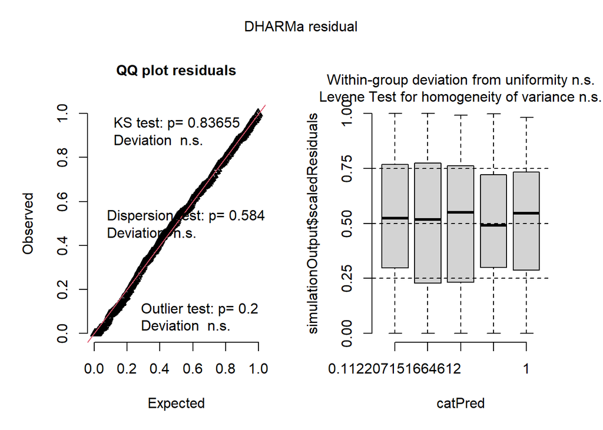

```r
abnd.resid <- abnd.glmmTMB2 %>% DHARMa::simulateResiduals(plot = T)
```

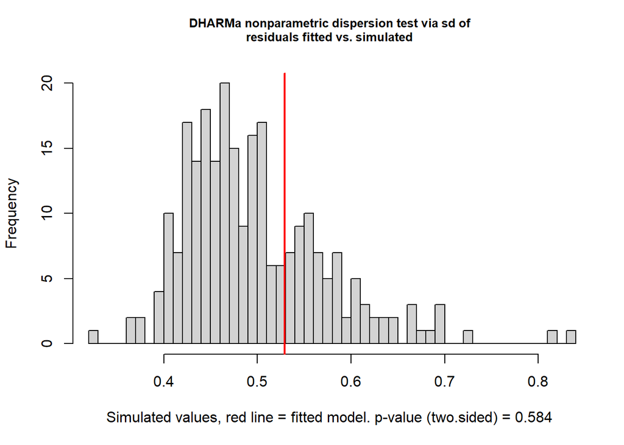

```
    DHARMa nonparametric dispersion test via sd of residuals fitted vs.
    simulated

data:  simulationOutput
dispersion = 1.0634, p-value = 0.584
alternative hypothesis: two.sided
```

```r
abnd.resid %>% testDispersion()
```

```r
fish.sp.abnd <- fish.sp.abnd %>%
  mutate(TIME = as.numeric(plotID) + as.numeric(Date) * 10^-5)
fish.sp.abnd %>% head()
```

```
  Treatment Replicate       Date abundance sp.richness plot.weight plotID
1        BH         1 2022-11-25         4           1         414    BH1
2        BH         1 2022-11-26         5           1         414    BH1
3        BH         1 2022-11-27         0           0         414    BH1
4        BH         1 2022-11-28        10           3         414    BH1
5        BH         1 2022-11-29         5           3         414    BH1
6        BH         1 2022-11-30         3           2         414    BH1
  Density    TIME
1       9 1.19321
2       9 1.19322
3       9 1.19323
4       9 1.19324
5       9 1.19325
6       9 1.19326
```

```r
fish.sp.abnd %>% tail()
```

```
    Treatment Replicate       Date abundance sp.richness plot.weight plotID
445         W         5 2022-12-07        18           5       674.1     W5
446         W         5 2022-12-08        18           5       674.1     W5
447         W         5 2022-12-09        19           5       674.1     W5
448         W         5 2022-12-10        15           6       674.1     W5
449         W         5 2022-12-11        23           5       674.1     W5
450         W         5 2022-12-12        27           6       674.1     W5
    Density     TIME
445       9 25.19333
446       9 25.19334
447       9 25.19335
448       9 25.19336
449       9 25.19337
450       9 25.19338
```

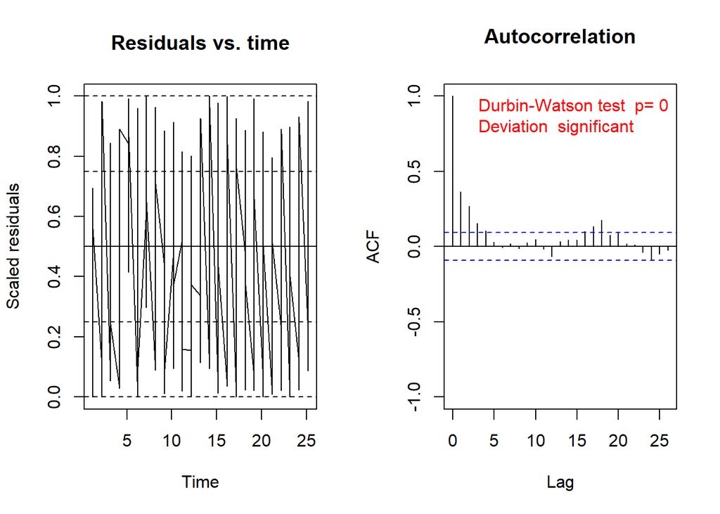

```
    Durbin-Watson test

data:  simulationOutput$scaledResiduals ~ 1
DW = 1.2606, p-value = 3.842e-15
alternative hypothesis: true autocorrelation is not 0
```

```r
abnd.resid %>% testTemporalAutocorrelation(time = fish.sp.abnd$TIME)
```

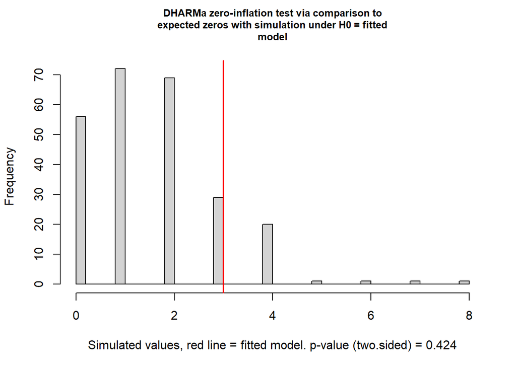

```
    DHARMa zero-inflation test via comparison to expected zeros with
    simulation under H0 = fitted model

data:  simulationOutput
ratioObsSim = 1.861, p-value = 0.424
alternative hypothesis: two.sided
```

```r
abnd.resid %>% testZeroInflation()
```

residuals look quite good. However, there appears to be definite autocorrelation No zero inflation

```r
abnd.glmmTMB.ac <- update(
  abnd.glmmTMB2, . ~ . +
    ar1(0 + factor(Date) | plotID)
)

AICc(abnd.glmmTMB.ac, abnd.glmmTMB2)
```

```
                df     AICc
abnd.glmmTMB.ac  8 2318.891
abnd.glmmTMB2    6 2397.659
```

autocorrelation model fit straight away, and is the definite winner by AICc despite higher df

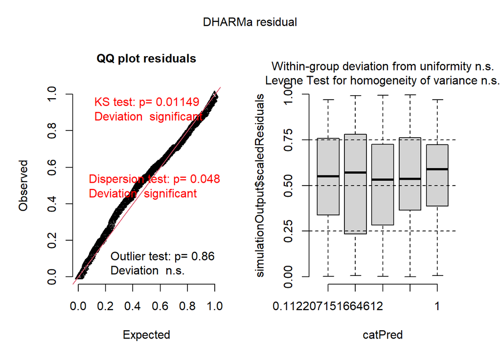

```r
abnd.resid <- abnd.glmmTMB.ac %>% simulateResiduals(plot = T)
```

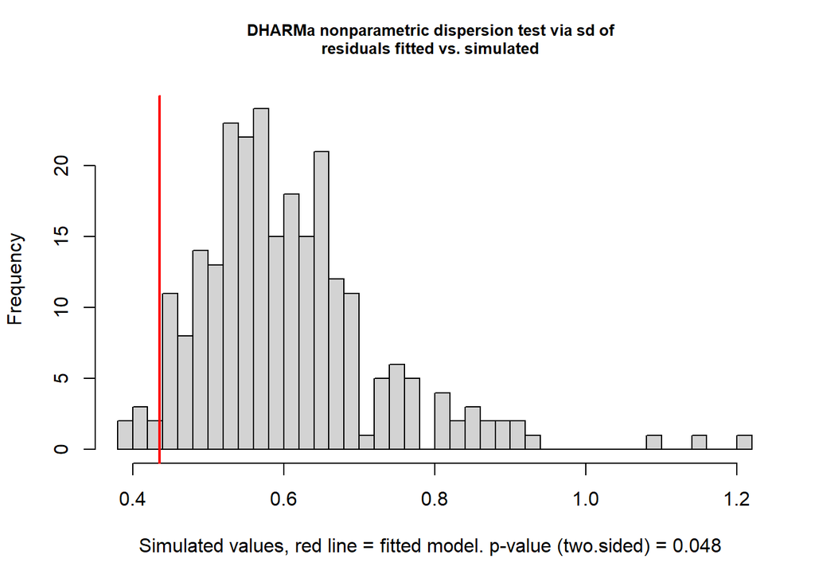

```
    DHARMa nonparametric dispersion test via sd of residuals fitted vs.
    simulated

data:  simulationOutput
dispersion = 0.71859, p-value = 0.048
alternative hypothesis: two.sided
```

```r
abnd.resid %>% testDispersion()
```

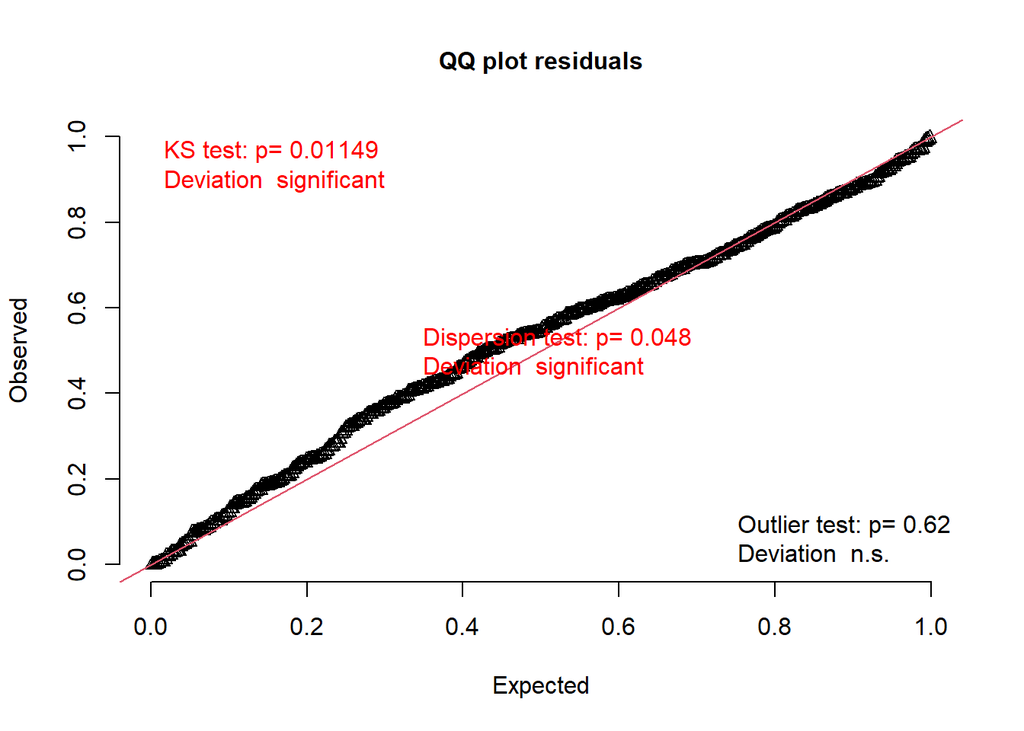

```
    Asymptotic one-sample Kolmogorov-Smirnov test

data:  simulationOutput$scaledResiduals
D = 0.075714, p-value = 0.01149
alternative hypothesis: two-sided
```

```r
abnd.resid %>% testUniformity()
```

However: (from https://rdrr.io/cran/DHARMa/man/testTemporalAutocorrelation.html)

Note Standard DHARMa simulations from models with (temporal / spatial / phylogenetic) conditional autoregressive terms will still have the respective temporal / spatial / phylogenetic correlation in the DHARMa residuals, unless the package you are using is modelling the autoregressive terms as explicit REs and is able to simulate conditional on the fitted REs. This has two consequences

If you check the residuals for such a model, they will still show significant autocorrelation, even if the model fully accounts for this structure.

Because the DHARMa residuals for such a model are not statistically independent any more, other tests (e.g. dispersion, uniformity) may have inflated type I error, i.e. you will have a higher likelihood of spurious residual problems.

There are three (non-exclusive) routes to address these issues when working with spatial / temporal / other autoregressive models:

Simulate conditional on the fitted CAR structures (see conditional simulations in the help of simulateResiduals)

Rotate simulations prior to residual calculations (see parameter rotation in simulateResiduals)

Use custom tests / plots that explicitly compare the correlation structure in the simulated data to the correlation structure in the observed data.

### 4.1.3 Partial Plot

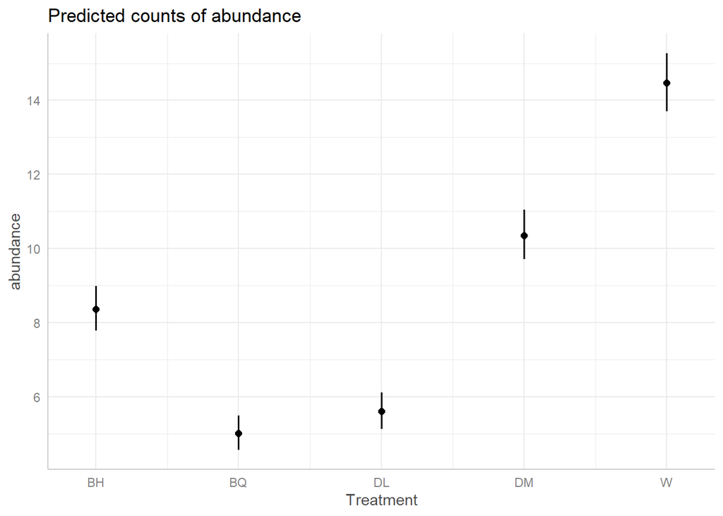

```r
abnd.glmmTMB2 %>%
  ggpredict(terms = "Treatment") %>%
  plot()
```

[figure not shown]

```r
abnd.glmmTMB.ac %>%
  ggpredict(terms = "Treatment") %>%
  plot()
```

### 4.1.4 Bayesian Model

#### 4.1.4.1 1 Initial priors

```r
abnd.form <- bf(
  abundance ~ Treatment
    + (1 | plotID),
  autocor = ~ ar(
    time = Date, gr = plotID,
    p = 1
  ),
  family = poisson(link = "log")
)

abnd.form %>% get_prior(data = fish.sp.abnd)
```

```
                  prior     class        coef  group resp dpar nlpar lb ub
                 (flat)        ar                                    -1  1
                 (flat)         b
                 (flat)         b TreatmentBQ
                 (flat)         b TreatmentDL
                 (flat)         b TreatmentDM
                 (flat)         b  TreatmentW
 student_t(3, 2.1, 2.5) Intercept
   student_t(3, 0, 2.5)        sd                                     0
   student_t(3, 0, 2.5)        sd             plotID                  0
   student_t(3, 0, 2.5)        sd   Intercept plotID                  0
   student_t(3, 0, 2.5)     sderr                                     0
       source
      default
      default
 (vectorized)
 (vectorized)
 (vectorized)
 (vectorized)
      default
      default
 (vectorized)
 (vectorized)
      default
```

```r
fish.sp.abnd %>%
  group_by(Treatment) %>%
  summarise(
    log(median(abundance)),
    log(mad(abundance))
  )
```

```
# A tibble: 5 × 3
  Treatment `log(median(abundance))` `log(mad(abundance))`
  <fct>                        <dbl>                 <dbl>
1 BH                            2.08                  1.09
2 BQ                            1.61                  1.09
3 DL                            1.61                  1.09
4 DM                            2.30                  1.09
5 W                             2.71                  1.49
```

The default priors were mostly flat for the effects and student_t for the sds. A prior I haven’t used before appeared - class ‘ar’ - flat, with an upper bound of 1 and a lower bound of -1. From the plots and eda, above, an appropriate estimate of the abundance in group BH (the default first) would be 8. On the log scale, log 8 = 2.0794415 ~ 2.1 (the same as brms would give for the median of the student_t for the Intercept). However the dispersion of 2.5 is likely too wide. In addition to an sd overall, an sd for the intercept and an sd by group = plotID, an additional ‘sderr’ term exists. This is the “standard deviation of latent residuals in latent ARMA models”.

for the intercept, a more appropriate prior might be N(2,1)

For the slope, sd(RESPONSE/sd(PREDICTOR) – gives a very crude approximation of the sd of the slope of that relationship. In this case our predictor is Categorical, so we have to use dummy code (0s and 1s)

```r
##priors for Effects
log(sd(fish.sp.abnd$abundance)) #1.61
```

```
[1] 1.61445
```

```r
model.matrix(~Treatment, data = fish.sp.abnd) %>% head
```

```
  (Intercept) TreatmentBQ TreatmentDL TreatmentDM TreatmentW
1           1           0           0           0          0
2           1           0           0           0          0
3           1           0           0           0          0
4           1           0           0           0          0
5           1           0           0           0          0
6           1           0           0           0          0
```

```r
apply(model.matrix(~Treatment, data = fish.sp.abnd), 2, sd)
```

```
(Intercept) TreatmentBQ TreatmentDL TreatmentDM  TreatmentW
  0.0000000   0.4004452   0.4004452   0.4004452   0.4004452
```

```r
log(sd(fish.sp.abnd$abundance))/apply(model.matrix(~Treatment, data = fish.sp.abnd), 2, sd)
```

```
(Intercept) TreatmentBQ TreatmentDL TreatmentDM  TreatmentW
        Inf    4.031637    4.031637    4.031637    4.031637
```

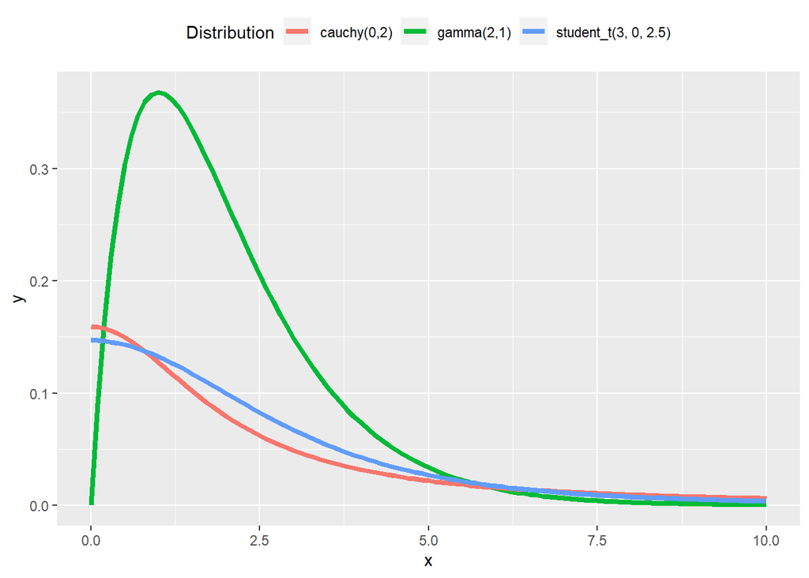

```r
standist::visualize("gamma(2,1)", "cauchy(0,2)","student_t(3, 0, 2.5)", xlim = c(0,10))
```

The sds are the same for each treatment because the study was balanced.

For the variance argument for the slope prior, a bit more than 4, say 4.5 or 5 (to allow a bit more width) would probably be appropriate i.e. N(0, 5)

For the sd prior, a cauchy (0,2) will be used to begin with. I’ll do the same with “sderr”